# (Visualizing FordGoBike Data)

## Preliminary Wrangling

### Introduce dataset .

Ford GoBike, like other bike share systems, consists of a fleet of specially designed, sturdy and durable bikes that are locked into a network of docking stations throughout the city. The bikes can be taken from one station and returned to any other in the system. People use bike share to go to work or school or more. The ride of bike fun, convenient and affordable way to get around. The bikes are available for use 24 hours/day, 7 days/week, 365 days/year and riders have access to all bikes in the network when they become a member or purchase a pass. Moreove, The dataset consist of approximately 819163 bike rides from 2018( Jan-Jun).

## Part III - Gathering Data

```python
# import all packages
import numpy as np
import pandas as pd
import matplotlib.pyplot as plt
import seaborn as sb
%matplotlib inline
import glob
import os
import datetime
```

> Load dataset. I have joined 6 files of dataset into one called 'master_file.csv'

```python
path = r'C:\Users\Asus\Downloads\gk'

all_files = glob.glob(os.path.join(path, "*.csv"))

df = pd.concat((pd.read_csv(f) for f in all_files), ignore_index = True)

df.to_csv('master_file.csv', index=False)
```

```python
df = pd.read_csv('master_file.csv')
```

## Part II - Assessing Data

```python
## showing first 60 rows to understand the data
df.sample(60)
```

|  | duration_sec | start_time | end_time | start_station_id | start_station_name | start_station_latitude | start_station_longitude | end_station_id | end_station_name | end_station_latitude | end_station_longitude | bike_id | user_type | bike_share_for_all_trip |
| --- | --- | --- | --- | --- | --- | --- | --- | --- | --- | --- | --- | --- | --- | --- |
| 726950 | 528 | 2018-06-15 08:37:46.6760 | 2018-06-15 08:46:35.6450 | 58.0 | Market St at 10th St | 37.776619 | -122.417385 | 21.0 | Montgomery St BART Station (Market St at 2nd St) | 37.789625 | -122.400811 | 2443 | Subscriber | No |
| 422719 | 92 | 2018-04-05 17:18:57.3570 | 2018-04-05 17:20:29.8590 | 114.0 | Rhode Island St at 17th St | 37.764478 | -122.402570 | 115.0 | Jackson Playground | 37.765026 | -122.398773 | 2011 | Subscriber | No |
| 154477 | 422 | 2018-02-12 17:09:54.3190 | 2018-02-12 17:16:56.5860 | 342.0 | Colin P Kelly Jr St at Townsend St (Temporary ... | 37.781383 | -122.389841 | 15.0 | San Francisco Ferry Building (Harry Bridges Pl... | 37.795392 | -122.394203 | 1330 | Subscriber | No |
| 514325 | 197 | 2018-05-19 12:26:39.6430 | 2018-05-19 12:29:56.6730 | 284.0 | Yerba Buena Center for the Arts (Howard St at ... | 37.784872 | -122.400876 | 284.0 | Yerba Buena Center for the Arts (Howard St at ... | 37.784872 | -122.400876 | 2139 | Customer | No |
| 608771 | 296 | 2018-05-03 08:32:30.7320 | 2018-05-03 08:37:27.2930 | 89.0 | Division St at Potrero Ave | 37.769218 | -122.407646 | 66.0 | 3rd St at Townsend St | 37.778742 | -122.392741 | 4063 | Subscriber | No |
| 221138 | 176 | 2018-03-27 18:01:01.8170 | 2018-03-27 18:03:58.4680 | 37.0 | 2nd St at Folsom St | 37.785000 | -122.395936 | 21.0 | Montgomery St BART Station (Market St at 2nd St) | 37.789625 | -122.400811 | 2401 | Subscriber | No |
| 556567 | 160 | 2018-05-11 20:05:58.2070 | 2018-05-11 20:08:39.1740 | 166.0 | College Ave at Alcatraz Ave | 37.851376 | -122.252523 | 171.0 | Rockridge BART Station | 37.844279 | -122.251900 | 570 | Subscriber | No |
| 554677 | 304 | 2018-05-12 12:43:38.9530 | 2018-05-12 12:48:43.9300 | 41.0 | Golden Gate Ave at Polk St | 37.781270 | -122.418740 | 3.0 | Powell St BART Station (Market St at 4th St) | 37.786375 | -122.404904 | 3682 | Subscriber | No |
| 517792 | 821 | 2018-05-18 16:51:32.1850 | 2018-05-18 17:05:13.8340 | 88.0 | 11th St at Bryant St | 37.770030 | -122.411726 | 23.0 | The Embarcadero at Steuart St | 37.791464 | -122.391034 | 1156 | Subscriber | No |
| 427115 | 1156 | 2018-04-04 18:00:32.6160 | 2018-04-04 18:19:49.5340 | 215.0 | 34th St at Telegraph Ave | 37.822547 | -122.266318 | 176.0 | MacArthur BART Station | 37.828410 | -122.266315 | 1585 | Subscriber | Yes |
| 733009 | 923 | 2018-06-14 11:37:04.1440 | 2018-06-14 11:52:27.4390 | 255.0 | Virginia St at Shattuck Ave | 37.876573 | -122.269528 | 240.0 | Haste St at Telegraph Ave | 37.866043 | -122.258804 | 227 | Subscriber | No |
| 310124 | 208 | 2018-03-02 06:49:35.4600 | 2018-03-02 06:53:04.3200 | 272.0 | Woolsey St at Sacramento St | 37.850578 | -122.278175 | 241.0 | Ashby BART Station | 37.852477 | -122.270213 | 1533 | Subscriber | No |
| 40833 | 602 | 2018-01-20 12:44:45.3840 | 2018-01-20 12:54:47.8020 | 28.0 | The Embarcadero at Bryant St | 37.787168 | -122.388098 | 81.0 | Berry St at 4th St | 37.775880 | -122.393170 | 2283 | Subscriber | No |
| 700621 | 163 | 2018-06-19 17:58:26.5980 | 2018-06-19 18:01:09.9730 | 338.0 | 13th St at Franklin St | 37.803189 | -122.270579 | 183.0 | Telegraph Ave at 19th St | 37.808702 | -122.269927 | 1889 | Subscriber | No |
| 642970 | 564 | 2018-06-28 05:36:43.1820 | 2018-06-28 05:46:07.3150 | 76.0 | McCoppin St at Valencia St | 37.771662 | -122.422423 | 3.0 | Powell St BART Station (Market St at 4th St) | 37.786375 | -122.404904 | 2397 | Subscriber | No |
| 181491 | 472 | 2018-02-06 08:47:52.7830 | 2018-02-06 08:55:45.2380 | 200.0 | 2nd Ave at E 18th St | 37.800214 | -122.253810 | 163.0 | Lake Merritt BART Station | 37.797320 | -122.265320 | 1642 | Subscriber | No |
| 543814 | 459 | 2018-05-14 18:08:48.0980 | 2018-05-14 18:16:27.8390 | 81.0 | Berry St at 4th St | 37.775880 | -122.393170 | 23.0 | The Embarcadero at Steuart St | 37.791464 | -122.391034 | 670 | Subscriber | No |
| 535074 | 574 | 2018-05-16 07:38:46.1380 | 2018-05-16 07:48:20.4050 | 336.0 | Potrero Ave and Mariposa St | 37.763281 | -122.407377 | 81.0 | Berry St at 4th St | 37.775880 | -122.393170 | 477 | Customer | No |
| 22960 | 1580 | 2018-01-25 17:44:38.6250 | 2018-01-25 18:10:59.1360 | 19.0 | Post St at Kearny St | 37.788975 | -122.403452 | 138.0 | Jersey St at Church St | 37.750900 | -122.427411 | 3593 | Subscriber | No |
| 4077 | 679 | 2018-01-31 07:53:04.5270 | 2018-01-31 08:04:23.5840 | 29.0 | O'Farrell St at Divisadero St | 37.782405 | -122.439446 | 59.0 | S Van Ness Ave at Market St | 37.774814 | -122.418954 | 2697 | Subscriber | No |
| 731839 | 813 | 2018-06-14 15:35:33.8410 | 2018-06-14 15:49:07.4360 | 79.0 | 7th St at Brannan St | 37.773492 | -122.403672 | 74.0 | Laguna St at Hayes St | 37.776435 | -122.426244 | 1668 | Subscriber | No |
| 230281 | 297 | 2018-03-25 17:06:04.0840 | 2018-03-25 17:11:01.5600 | 95.0 | Sanchez St at 15th St | 37.766219 | -122.431060 | 223.0 | 16th St Mission BART Station 2 | 37.764765 | -122.420091 | 770 | Subscriber | No |
| 247431 | 469 | 2018-03-20 17:15:42.9950 | 2018-03-20 17:23:32.2600 | 342.0 | Colin P Kelly Jr St at Townsend St (Temporary ... | 37.781383 | -122.389841 | 15.0 | San Francisco Ferry Building (Harry Bridges Pl... | 37.795392 | -122.394203 | 1497 | Subscriber | No |
| 48443 | 461 | 2018-01-17 20:18:26.6090 | 2018-01-17 20:26:07.6640 | 238.0 | MLK Jr Way at University Ave | 37.871719 | -122.273068 | 238.0 | MLK Jr Way at University Ave | 37.871719 | -122.273068 | 2405 | Subscriber | No |
| 252648 | 887 | 2018-03-19 09:32:17.0970 | 2018-03-19 09:47:04.5980 | 15.0 | San Francisco Ferry Building (Harry Bridges Pl... | 37.795392 | -122.394203 | 93.0 | 4th St at Mission Bay Blvd S | 37.770407 | -122.391198 | 1497 | Subscriber | No |
| 789015 | 698 | 2018-06-05 18:59:08.3540 | 2018-06-05 19:10:47.0360 | 61.0 | Howard St at 8th St | 37.776513 | -122.411306 | 42.0 | San Francisco City Hall (Polk St at Grove St) | 37.778650 | -122.418230 | 3390 | Subscriber | No |
| 53569 | 739 | 2018-01-16 18:05:55.1310 | 2018-01-16 18:18:14.2630 | 11.0 | Davis St at Jackson St | 37.797280 | -122.398436 | 81.0 | Berry St at 4th St | 37.775880 | -122.393170 | 2080 | Subscriber | No |
| 363301 | 374 | 2018-04-20 15:08:39.3580 | 2018-04-20 15:14:53.7190 | 60.0 | 8th St at Ringold St | 37.774520 | -122.409449 | 5.0 | Powell St BART Station (Market St at 5th St) | 37.783899 | -122.408445 | 1156 | Subscriber | Yes |
| 23320 | 151 | 2018-01-25 17:27:01.3920 | 2018-01-25 17:29:32.7990 | 93.0 | 4th St at Mission Bay Blvd S | 37.770407 | -122.391198 | 81.0 | Berry St at 4th St | 37.775880 | -122.393170 | 2303 | Subscriber | No |
| 330871 | 500 | 2018-04-27 08:50:18.8350 | 2018-04-27 08:58:38.9610 | 19.0 | Post St at Kearny St | 37.788975 | -122.403452 | 50.0 | 2nd St at Townsend St | 37.780526 | -122.390288 | 3839 | Subscriber | No |
| 742847 | 272 | 2018-06-13 08:24:02.8480 | 2018-06-13 08:28:35.0460 | 66.0 | 3rd St at Townsend St | 37.778742 | -122.392741 | 37.0 | 2nd St at Folsom St | 37.785000 | -122.395936 | 1673 | Subscriber | No |
| 262309 | 373 | 2018-03-15 18:24:40.7580 | 2018-03-15 18:30:54.6700 | 26.0 | 1st St at Folsom St | 37.787290 | -122.394380 | 30.0 | San Francisco Caltrain (Townsend St at 4th St) | 37.776598 | -122.395282 | 2766 | Subscriber | No |
| 114482 | 414 | 2018-02-23 06:56:35.5170 | 2018-02-23 07:03:29.8260 | 60.0 | 8th St at Ringold St | 37.774520 | -122.409449 | 3.0 | Powell St BART Station (Market St at 4th St) | 37.786375 | -122.404904 | 1563 | Subscriber | No |
| 267556 | 1866 | 2018-03-14 14:20:33.2280 | 2018-03-14 14:51:39.6440 | 20.0 | Mechanics Monument Plaza (Market St at Bush St) | 37.791300 | -122.399051 | 6.0 | The Embarcadero at Sansome St | 37.804770 | -122.403234 | 2811 | Customer | No |
| 510143 | 1894 | 2018-05-20 13:03:04.4970 | 2018-05-20 13:34:38.8360 | 93.0 | 4th St at Mission Bay Blvd S | 37.770407 | -122.391198 | 101.0 | San Bruno Ave at 16th St | 37.766008 | -122.405677 | 1516 | Customer | No |
| 355744 | 619 | 2018-04-22 19:15:58.9580 | 2018-04-22 19:26:18.8770 | 133.0 | Valencia St at 22nd St | 37.755213 | -122.420975 | 133.0 | Valencia St at 22nd St | 37.755213 | -122.420975 | 706 | Subscriber | No |
| 393416 | 1334 | 2018-04-13 09:52:08.3570 | 2018-04-13 10:14:23.1020 | 71.0 | Broderick St at Oak St | 37.773063 | -122.439078 | 21.0 | Montgomery St BART Station (Market St at 2nd St) | 37.789625 | -122.400811 | 1524 | Customer | No |
| 104805 | 383 | 2018-02-26 17:04:06.1710 | 2018-02-26 17:10:29.7620 | 44.0 | Civic Center/UN Plaza BART Station (Market St ... | 37.781074 | -122.411738 | 61.0 | Howard St at 8th St | 37.776513 | -122.411306 | 2754 | Subscriber | No |
| 790033 | 429 | 2018-06-05 17:52:11.0790 | 2018-06-05 17:59:20.5120 | 284.0 | Yerba Buena Center for the Arts (Howard St at ... | 37.784872 | -122.400876 | 350.0 | 8th St at Brannan St | 37.771431 | -122.405787 | 1067 | Subscriber | No |
| 87773 | 383 | 2018-01-03 17:59:38.9770 | 2018-01-03 18:06:02.2900 | 10.0 | Washington St at Kearny St | 37.795393 | -122.404770 | 20.0 | Mechanics Monument Plaza (Market St at Bush St) | 37.791300 | -122.399051 | 93 | Subscriber | No |
| 434376 | 6604 | 2018-04-03 10:40:30.4960 | 2018-04-03 12:30:35.0440 | 71.0 | Broderick St at Oak St | 37.773063 | -122.439078 | 8.0 | The Embarcadero at Vallejo St | 37.799953 | -122.398525 | 1241 | Customer | No |
| 559316 | 242 | 2018-05-11 14:50:06.7030 | 2018-05-11 14:54:09.0860 | 43.0 | San Francisco Public Library (Grove St at Hyde... | 37.778768 | -122.415929 | 59.0 | S Van Ness Ave at Market St | 37.774814 | -122.418954 | 1627 | Subscriber | No |
| 309705 | 287 | 2018-03-02 08:31:29.1250 | 2018-03-02 08:36:17.0700 | 119.0 | 18th St at Noe St | 37.761047 | -122.432642 | 84.0 | Duboce Park | 37.769200 | -122.433812 | 210 | Subscriber | No |
| 467457 | 200 | 2018-05-28 12:23:23.6110 | 2018-05-28 12:26:44.2670 | 78.0 | Folsom St at 9th St | 37.773717 | -122.411647 | 350.0 | 8th St at Brannan St | 37.771431 | -122.405787 | 1133 | Subscriber | No |
| 40143 | 1552 | 2018-01-20 15:17:42.4290 | 2018-01-20 15:43:35.1720 | 245.0 | Downtown Berkeley BART | 37.870348 | -122.267764 | 174.0 | Shattuck Ave at 51st St | 37.836801 | -122.264004 | 2040 | Subscriber | No |
| 343982 | 443 | 2018-04-25 07:18:58.5430 | 2018-04-25 07:26:22.0340 | 78.0 | Folsom St at 9th St | 37.773717 | -122.411647 | 67.0 | San Francisco Caltrain Station 2 (Townsend St... | 37.776639 | -122.395526 | 2076 | Subscriber | No |
| 133825 | 651 | 2018-02-16 19:57:58.9130 | 2018-02-16 20:08:50.7900 | 58.0 | Market St at 10th St | 37.776619 | -122.417385 | 36.0 | Folsom St at 3rd St | 37.783830 | -122.398870 | 1045 | Subscriber | No |
| 676507 | 1153 | 2018-06-22 20:42:26.7100 | 2018-06-22 21:01:39.9210 | 160.0 | West Oakland BART Station | 37.805318 | -122.294837 | 150.0 | Adeline St at 40th St | 37.831277 | -122.278267 | 3126 | Subscriber | No |
| 563827 | 833 | 2018-05-10 18:58:27.8310 | 2018-05-10 19:12:21.6290 | 63.0 | Bryant St at 6th St | 37.775910 | -122.402575 | 19.0 | Post St at Kearny St | 37.788975 | -122.403452 | 746 | Customer | No |
| 518670 | 468 | 2018-05-18 14:52:19.2310 | 2018-05-18 15:00:08.0240 | 20.0 | Mechanics Monument Plaza (Market St at Bush St) | 37.791300 | -122.399051 | 5.0 | Powell St BART Station (Market St at 5th St) | 37.783899 | -122.408445 | 3879 | Subscriber | No |
| 47779 | 272 | 2018-01-18 07:50:56.5670 | 2018-01-18 07:55:28.8210 | 17.0 | Embarcadero BART Station (Beale St at Market St) | 37.792251 | -122.397086 | 8.0 | The Embarcadero at Vallejo St | 37.799953 | -122.398525 | 1840 | Subscriber | Yes |
| 4060 | 885 | 2018-01-31 07:51:18.9270 | 2018-01-31 08:06:04.5850 | 18.0 | Telegraph Ave at Alcatraz Ave | 37.850222 | -122.260172 | 241.0 | Ashby BART Station | 37.852477 | -122.270213 | 1291 | Subscriber | No |
| 158576 | 1450 | 2018-02-11 13:15:34.8030 | 2018-02-11 13:39:45.3870 | 144.0 | Precita Park | 37.747300 | -122.411403 | 52.0 | McAllister St at Baker St | 37.777416 | -122.441838 | 3595 | Subscriber | No |
| 195630 | 662 | 2018-02-02 09:07:27.3930 | 2018-02-02 09:18:29.8510 | 74.0 | Laguna St at Hayes St | 37.776435 | -122.426244 | 3.0 | Powell St BART Station (Market St at 4th St) | 37.786375 | -122.404904 | 3591 | Subscriber | No |
| 370311 | 198 | 2018-04-19 08:34:09.9910 | 2018-04-19 08:37:28.3520 | 196.0 | Grand Ave at Perkins St | 37.808894 | -122.256460 | 181.0 | Grand Ave at Webster St | 37.811377 | -122.265192 | 3349 | Subscriber | No |
| 458770 | 203 | 2018-05-29 19:12:20.2180 | 2018-05-29 19:15:44.2050 | 67.0 | San Francisco Caltrain Station 2 (Townsend St... | 37.776639 | -122.395526 | 90.0 | Townsend St at 7th St | 37.771058 | -122.402717 | 1424 | Subscriber | No |
| 107666 | 421 | 2018-02-25 15:41:48.5550 | 2018-02-25 15:48:50.0010 | 78.0 | Folsom St at 9th St | 37.773717 | -122.411647 | 36.0 | Folsom St at 3rd St | 37.783830 | -122.398870 | 1796 | Subscriber | No |
| 442285 | 316 | 2018-04-01 18:41:58.3310 | 2018-04-01 18:47:14.6500 | 88.0 | 11th St at Bryant St | 37.770030 | -122.411726 | 63.0 | Bryant St at 6th St | 37.775910 | -122.402575 | 2729 | Subscriber | No |
| 399928 | 737 | 2018-04-11 21:26:44.7280 | 2018-04-11 21:39:02.6620 | 245.0 | Downtown Berkeley BART | 37.870348 | -122.267764 | 267.0 | Derby St at College Ave | 37.861804 | -122.253569 | 2437 | Subscriber | No |
| 753099 | 552 | 2018-06-11 18:28:12.4310 | 2018-06-11 18:37:25.0540 | 163.0 | Lake Merritt BART Station | 37.797320 | -122.265320 | 196.0 | Grand Ave at Perkins St | 37.808894 | -122.256460 | 309 | Customer | No |

```python
## look for null values and more info
df.info()
```

```
<class 'pandas.core.frame.DataFrame'>
RangeIndex: 819164 entries, 0 to 819163
Data columns (total 14 columns):
 #   Column                   Non-Null Count   Dtype
---  ------                   --------------   -----
 0   duration_sec             819164 non-null  int64
 1   start_time               819164 non-null  object
 2   end_time                 819164 non-null  object
 3   start_station_id         817103 non-null  float64
 4   start_station_name       817103 non-null  object
 5   start_station_latitude   819164 non-null  float64
 6   start_station_longitude  819164 non-null  float64
 7   end_station_id           817103 non-null  float64
 8   end_station_name         817103 non-null  object
 9   end_station_latitude     819164 non-null  float64
 10  end_station_longitude    819164 non-null  float64
 11  bike_id                  819164 non-null  int64
 12  user_type                819164 non-null  object
 13  bike_share_for_all_trip  819164 non-null  object
dtypes: float64(6), int64(2), object(6)
memory usage: 87.5+ MB
```

```python
## Check for duplicate values
df.duplicated().sum()
```

```
0
```

```python
# View descriptive statistics
df.describe()
```

|  | duration_sec | start_station_id | start_station_latitude | start_station_longitude | end_station_id | end_station_latitude | end_station_longitude | bike_id |
| --- | --- | --- | --- | --- | --- | --- | --- | --- |
| count | 819164.000000 | 817103.000000 | 819164.000000 | 819164.000000 | 817103.000000 | 819164.000000 | 819164.000000 | 819164.000000 |
| mean | 879.605099 | 113.110619 | 37.767413 | -122.351751 | 111.284454 | 37.767557 | -122.351111 | 2187.603797 |
| std | 2576.385421 | 94.816424 | 0.103012 | 0.180935 | 94.562349 | 0.102895 | 0.180561 | 1188.942033 |
| min | 61.000000 | 3.000000 | 37.312854 | -122.444293 | 3.000000 | 37.312854 | -122.444293 | 11.000000 |
| 25% | 350.000000 | 30.000000 | 37.771058 | -122.411726 | 30.000000 | 37.771058 | -122.410807 | 1182.000000 |
| 50% | 554.000000 | 81.000000 | 37.781270 | -122.397405 | 81.000000 | 37.781383 | -122.397380 | 2283.000000 |
| 75% | 870.000000 | 179.000000 | 37.795393 | -122.291360 | 178.000000 | 37.795812 | -122.291376 | 3209.000000 |
| max | 86366.000000 | 356.000000 | 45.510000 | -73.570000 | 356.000000 | 45.510000 | -73.570000 | 4307.000000 |

#### Quality issues

1. start_time and end_time are objects not a timestamps
2. bike id, start_station_id, end_station_id should be set to object
3. we can enhance the dataset with more details like month, day, hour, weekday to use it in our investigation

## Part III - Cleaning Data

```python
# Create copies of original dataframes to work with
df_clean = df.copy()
```

```python
#Define1: change start_time and end_time to timestamps

#code
df_clean.start_time = pd.to_datetime(df_clean.start_time)
df_clean.end_time = pd.to_datetime(df_clean.end_time)
```

```python
#Define2: change bike id, start_station_id, end_station_id to object

#code
df_clean.bike_id = df_clean.bike_id.astype(str)
df_clean.start_station_id = df_clean.start_station_id.astype(str)
df_clean.end_station_id = df_clean.end_station_id.astype(str)

#Test define 1 and 2
df_clean.info()
```

```
<class 'pandas.core.frame.DataFrame'>
RangeIndex: 819164 entries, 0 to 819163
Data columns (total 14 columns):
 #   Column                   Non-Null Count   Dtype
---  ------                   --------------   -----
 0   duration_sec             819164 non-null  int64
 1   start_time               819164 non-null  datetime64[ns]
 2   end_time                 819164 non-null  datetime64[ns]
 3   start_station_id         819164 non-null  object
 4   start_station_name       817103 non-null  object
 5   start_station_latitude   819164 non-null  float64
 6   start_station_longitude  819164 non-null  float64
 7   end_station_id           819164 non-null  object
 8   end_station_name         817103 non-null  object
 9   end_station_latitude     819164 non-null  float64
 10  end_station_longitude    819164 non-null  float64
 11  bike_id                  819164 non-null  object
 12  user_type                819164 non-null  object
 13  bike_share_for_all_trip  819164 non-null  object
dtypes: datetime64[ns](2), float64(4), int64(1), object(7)
memory usage: 87.5+ MB
```

```python
# Start time month (January - June)
df_clean['start_time_month'] = df_clean['start_time'].dt.strftime('%B')
```

```python
# get dayofweek and hours information from the start_time
df_clean['start_time_dayofweek']= df_clean['start_time'].dt.strftime('%a')
```

```python
# get start time by day
df_clean['start_time_day']=df_clean['start_time'].dt.day.astype(int)
```

```python
# get start time hour
df_clean['start_time_hour']=df_clean['start_time'].dt.hour
```

```python
# Convert the duration of ride from seconds to minutes
df_clean['duration_min'] = df_clean['duration_sec']/60
df_clean['duration_min'] = df_clean['duration_min'].astype(int)
```

```python
## Show the new columns has been added above
df_clean.sample(60)
```

|  | duration_sec | start_time | end_time | start_station_id | start_station_name | start_station_latitude | start_station_longitude | end_station_id | end_station_name | end_station_latitude | end_station_longitude | bike_id | user_type | bike_share_for_all_trip | start_time_month | start_time_dayofweek | start_time_day | start_time_hour | duration_min |
| --- | --- | --- | --- | --- | --- | --- | --- | --- | --- | --- | --- | --- | --- | --- | --- | --- | --- | --- | --- |
| 41851 | 256 | 2018-01-19 20:48:27.062 | 2018-01-19 20:52:43.136 | 160.0 | West Oakland BART Station | 37.805318 | -122.294837 | 235.0 | Union St at 10th St | 37.807239 | -122.289370 | 2482 | Subscriber | No | January | Fri | 19 | 20 | 4 |
| 608381 | 566 | 2018-05-03 08:54:50.144 | 2018-05-03 09:04:16.191 | 30.0 | San Francisco Caltrain (Townsend St at 4th St) | 37.776598 | -122.395282 | 60.0 | 8th St at Ringold St | 37.774520 | -122.409449 | 1090 | Subscriber | No | May | Thu | 3 | 8 | 9 |
| 606630 | 2128 | 2018-05-03 13:59:07.751 | 2018-05-03 14:34:36.528 | 43.0 | San Francisco Public Library (Grove St at Hyde... | 37.778768 | -122.415929 | 29.0 | O'Farrell St at Divisadero St | 37.782405 | -122.439446 | 1245 | Customer | No | May | Thu | 3 | 13 | 35 |
| 434892 | 175 | 2018-04-03 10:08:46.749 | 2018-04-03 10:11:42.093 | 66.0 | 3rd St at Townsend St | 37.778742 | -122.392741 | 66.0 | 3rd St at Townsend St | 37.778742 | -122.392741 | 1445 | Subscriber | No | April | Tue | 3 | 10 | 2 |
| 672901 | 382 | 2018-06-23 17:18:56.134 | 2018-06-23 17:25:18.164 | 28.0 | The Embarcadero at Bryant St | 37.787168 | -122.388098 | 16.0 | Steuart St at Market St | 37.794130 | -122.394430 | 1166 | Subscriber | No | June | Sat | 23 | 17 | 6 |
| 247854 | 949 | 2018-03-20 14:03:22.474 | 2018-03-20 14:19:11.670 | 15.0 | San Francisco Ferry Building (Harry Bridges Pl... | 37.795392 | -122.394203 | 284.0 | Yerba Buena Center for the Arts (Howard St at ... | 37.784872 | -122.400876 | 3578 | Subscriber | No | March | Tue | 20 | 14 | 15 |
| 33888 | 1161 | 2018-01-22 20:20:02.939 | 2018-01-22 20:39:24.836 | 3.0 | Powell St BART Station (Market St at 4th St) | 37.786375 | -122.404904 | 127.0 | Valencia St at 21st St | 37.756708 | -122.421025 | 1672 | Subscriber | Yes | January | Mon | 22 | 20 | 19 |
| 122512 | 741 | 2018-02-21 08:25:45.311 | 2018-02-21 08:38:06.487 | 144.0 | Precita Park | 37.747300 | -122.411403 | 130.0 | 22nd St Caltrain Station | 37.757369 | -122.392057 | 3372 | Subscriber | No | February | Wed | 21 | 8 | 12 |
| 663227 | 710 | 2018-06-25 13:59:31.066 | 2018-06-25 14:11:21.188 | 10.0 | Washington St at Kearny St | 37.795393 | -122.404770 | 47.0 | 4th St at Harrison St | 37.780955 | -122.399749 | 1166 | Subscriber | Yes | June | Mon | 25 | 13 | 11 |
| 680541 | 627 | 2018-06-22 12:21:37.700 | 2018-06-22 12:32:04.759 | 88.0 | 11th St at Bryant St | 37.770030 | -122.411726 | 127.0 | Valencia St at 21st St | 37.756708 | -122.421025 | 3901 | Subscriber | No | June | Fri | 22 | 12 | 10 |
| 170231 | 573 | 2018-02-08 11:38:20.852 | 2018-02-08 11:47:53.866 | 125.0 | 20th St at Bryant St | 37.759200 | -122.409851 | 102.0 | Irwin St at 8th St | 37.766883 | -122.399579 | 1282 | Subscriber | No | February | Thu | 8 | 11 | 9 |
| 262874 | 618 | 2018-03-15 17:07:37.323 | 2018-03-15 17:17:55.813 | 41.0 | Golden Gate Ave at Polk St | 37.781270 | -122.418740 | 67.0 | San Francisco Caltrain Station 2 (Townsend St... | 37.776639 | -122.395526 | 1245 | Subscriber | No | March | Thu | 15 | 17 | 10 |
| 359700 | 1581 | 2018-04-21 13:49:54.103 | 2018-04-21 14:16:15.798 | 70.0 | Central Ave at Fell St | 37.773311 | -122.444293 | 29.0 | O'Farrell St at Divisadero St | 37.782405 | -122.439446 | 1864 | Customer | No | April | Sat | 21 | 13 | 26 |
| 41796 | 374 | 2018-01-19 21:33:15.902 | 2018-01-19 21:39:30.887 | 9.0 | Broadway at Battery St | 37.798572 | -122.400869 | 21.0 | Montgomery St BART Station (Market St at 2nd St) | 37.789625 | -122.400811 | 126 | Subscriber | No | January | Fri | 19 | 21 | 6 |
| 216967 | 208 | 2018-03-28 15:36:03.450 | 2018-03-28 15:39:31.667 | 196.0 | Grand Ave at Perkins St | 37.808894 | -122.256460 | 197.0 | El Embarcadero at Grand Ave | 37.808848 | -122.249680 | 1050 | Subscriber | No | March | Wed | 28 | 15 | 3 |
| 85636 | 912 | 2018-01-04 13:54:24.031 | 2018-01-04 14:09:36.789 | 81.0 | Berry St at 4th St | 37.775880 | -122.393170 | 34.0 | Father Alfred E Boeddeker Park | 37.783988 | -122.412408 | 2794 | Subscriber | No | January | Thu | 4 | 13 | 15 |
| 564496 | 581 | 2018-05-10 18:06:32.765 | 2018-05-10 18:16:13.861 | 171.0 | Rockridge BART Station | 37.844279 | -122.251900 | 267.0 | Derby St at College Ave | 37.861804 | -122.253569 | 1576 | Subscriber | No | May | Thu | 10 | 18 | 9 |
| 489151 | 366 | 2018-05-23 20:08:45.250 | 2018-05-23 20:14:51.458 | 175.0 | 49th St at Telegraph Ave | 37.835946 | -122.262366 | 18.0 | Telegraph Ave at Alcatraz Ave | 37.850222 | -122.260172 | 3438 | Subscriber | No | May | Wed | 23 | 20 | 6 |
| 510179 | 1774 | 2018-05-20 12:59:15.790 | 2018-05-20 13:28:50.712 | 6.0 | The Embarcadero at Sansome St | 37.804770 | -122.403234 | 323.0 | Broadway at Kearny | 37.798014 | -122.405950 | 2079 | Customer | No | May | Sun | 20 | 12 | 29 |
| 539433 | 95 | 2018-05-15 12:43:07.828 | 2018-05-15 12:44:43.563 | 27.0 | Beale St at Harrison St | 37.788059 | -122.391865 | 22.0 | Howard St at Beale St | 37.789756 | -122.394643 | 1901 | Subscriber | No | May | Tue | 15 | 12 | 1 |
| 648581 | 778 | 2018-06-27 09:21:17.643 | 2018-06-27 09:34:16.270 | 66.0 | 3rd St at Townsend St | 37.778742 | -122.392741 | 22.0 | Howard St at Beale St | 37.789756 | -122.394643 | 536 | Subscriber | No | June | Wed | 27 | 9 | 12 |
| 244540 | 207 | 2018-03-21 14:37:35.034 | 2018-03-21 14:41:02.641 | 247.0 | Fulton St at Bancroft Way | 37.867789 | -122.265896 | 266.0 | Parker St at Fulton St | 37.862464 | -122.264791 | 269 | Subscriber | Yes | March | Wed | 21 | 14 | 3 |
| 553783 | 787 | 2018-05-12 15:01:00.388 | 2018-05-12 15:14:07.605 | 98.0 | Valencia St at 16th St | 37.765052 | -122.421866 | 85.0 | Church St at Duboce Ave | 37.770083 | -122.429156 | 2916 | Subscriber | No | May | Sat | 12 | 15 | 13 |
| 115304 | 689 | 2018-02-22 18:28:19.328 | 2018-02-22 18:39:48.567 | 22.0 | Howard St at Beale St | 37.789756 | -122.394643 | 61.0 | Howard St at 8th St | 37.776513 | -122.411306 | 1605 | Subscriber | No | February | Thu | 22 | 18 | 11 |
| 268378 | 1720 | 2018-03-14 08:53:59.590 | 2018-03-14 09:22:40.293 | 78.0 | Folsom St at 9th St | 37.773717 | -122.411647 | 15.0 | San Francisco Ferry Building (Harry Bridges Pl... | 37.795392 | -122.394203 | 1984 | Customer | No | March | Wed | 14 | 8 | 28 |
| 123876 | 487 | 2018-02-20 18:41:24.681 | 2018-02-20 18:49:32.445 | 62.0 | Victoria Manalo Draves Park | 37.777791 | -122.406432 | 30.0 | San Francisco Caltrain (Townsend St at 4th St) | 37.776598 | -122.395282 | 3385 | Subscriber | No | February | Tue | 20 | 18 | 8 |
| 520957 | 619 | 2018-05-18 08:26:22.412 | 2018-05-18 08:36:41.429 | 60.0 | 8th St at Ringold St | 37.774520 | -122.409449 | 3.0 | Powell St BART Station (Market St at 4th St) | 37.786375 | -122.404904 | 1816 | Subscriber | No | May | Fri | 18 | 8 | 10 |
| 364165 | 516 | 2018-04-20 11:02:50.769 | 2018-04-20 11:11:27.293 | 23.0 | The Embarcadero at Steuart St | 37.791464 | -122.391034 | 81.0 | Berry St at 4th St | 37.775880 | -122.393170 | 1593 | Subscriber | No | April | Fri | 20 | 11 | 8 |
| 621597 | 548 | 2018-05-01 09:08:25.303 | 2018-05-01 09:17:33.487 | 3.0 | Powell St BART Station (Market St at 4th St) | 37.786375 | -122.404904 | 37.0 | 2nd St at Folsom St | 37.785000 | -122.395936 | 2929 | Subscriber | No | May | Tue | 1 | 9 | 9 |
| 302679 | 431 | 2018-03-05 09:25:25.321 | 2018-03-05 09:32:36.648 | 231.0 | 14th St at Filbert St | 37.808750 | -122.283282 | 160.0 | West Oakland BART Station | 37.805318 | -122.294837 | 2870 | Subscriber | No | March | Mon | 5 | 9 | 7 |
| 458448 | 492 | 2018-05-29 19:46:54.333 | 2018-05-29 19:55:06.943 | 201.0 | 10th St at Fallon St | 37.797673 | -122.262997 | 195.0 | Bay Pl at Vernon St | 37.812314 | -122.260779 | 1097 | Subscriber | No | May | Tue | 29 | 19 | 8 |
| 440845 | 654 | 2018-04-02 08:49:01.349 | 2018-04-02 08:59:55.641 | 22.0 | Howard St at Beale St | 37.789756 | -122.394643 | 5.0 | Powell St BART Station (Market St at 5th St) | 37.783899 | -122.408445 | 3077 | Subscriber | No | April | Mon | 2 | 8 | 10 |
| 691603 | 695 | 2018-06-20 20:25:20.624 | 2018-06-20 20:36:56.546 | 21.0 | Montgomery St BART Station (Market St at 2nd St) | 37.789625 | -122.400811 | 58.0 | Market St at 10th St | 37.776619 | -122.417385 | 2148 | Subscriber | No | June | Wed | 20 | 20 | 11 |
| 238975 | 559 | 2018-03-22 19:46:14.838 | 2018-03-22 19:55:34.510 | 60.0 | 8th St at Ringold St | 37.774520 | -122.409449 | 22.0 | Howard St at Beale St | 37.789756 | -122.394643 | 2915 | Subscriber | No | March | Thu | 22 | 19 | 9 |
| 570182 | 704 | 2018-05-10 07:06:19.082 | 2018-05-10 07:18:03.883 | 312.0 | San Jose Diridon Station | 37.329732 | -121.901782 | 310.0 | San Fernando St at 4th St | 37.335885 | -121.885660 | 2434 | Customer | No | May | Thu | 10 | 7 | 11 |
| 477837 | 157 | 2018-05-25 17:09:17.054 | 2018-05-25 17:11:55.004 | 198.0 | Snow Park | 37.807813 | -122.264496 | 182.0 | 19th Street BART Station | 37.809013 | -122.268247 | 1953 | Subscriber | No | May | Fri | 25 | 17 | 2 |
| 103181 | 848 | 2018-02-27 07:42:08.169 | 2018-02-27 07:56:16.359 | 19.0 | Post St at Kearny St | 37.788975 | -122.403452 | 90.0 | Townsend St at 7th St | 37.771058 | -122.402717 | 3188 | Subscriber | No | February | Tue | 27 | 7 | 14 |
| 388142 | 2821 | 2018-04-14 15:51:46.329 | 2018-04-14 16:38:47.644 | 231.0 | 14th St at Filbert St | 37.808750 | -122.283282 | 180.0 | Telegraph Ave at 23rd St | 37.812678 | -122.268773 | 1585 | Customer | No | April | Sat | 14 | 15 | 47 |
| 380330 | 264 | 2018-04-17 08:45:25.339 | 2018-04-17 08:49:50.311 | 58.0 | Market St at 10th St | 37.776619 | -122.417385 | 89.0 | Division St at Potrero Ave | 37.769218 | -122.407646 | 484 | Subscriber | No | April | Tue | 17 | 8 | 4 |
| 102331 | 489 | 2018-02-27 09:10:09.270 | 2018-02-27 09:18:18.947 | 114.0 | Rhode Island St at 17th St | 37.764478 | -122.402570 | 49.0 | S Park St at 3rd St | 37.780760 | -122.394989 | 3210 | Subscriber | No | February | Tue | 27 | 9 | 8 |
| 810875 | 416 | 2018-06-02 12:27:21.284 | 2018-06-02 12:34:18.000 | 235.0 | Union St at 10th St | 37.807239 | -122.289370 | 162.0 | Franklin St at 9th St | 37.800516 | -122.272080 | 3310 | Subscriber | Yes | June | Sat | 2 | 12 | 6 |
| 628895 | 977 | 2018-06-29 18:18:11.931 | 2018-06-29 18:34:29.248 | 58.0 | Market St at 10th St | 37.776619 | -122.417385 | 109.0 | 17th St at Valencia St | 37.763316 | -122.421904 | 210 | Customer | No | June | Fri | 29 | 18 | 16 |
| 736430 | 603 | 2018-06-13 20:59:28.271 | 2018-06-13 21:09:31.858 | 14.0 | Clay St at Battery St | 37.795001 | -122.399970 | 5.0 | Powell St BART Station (Market St at 5th St) | 37.783899 | -122.408445 | 2495 | Subscriber | No | June | Wed | 13 | 20 | 10 |
| 209076 | 665 | 2018-03-29 22:33:05.029 | 2018-03-29 22:44:10.175 | 267.0 | Derby St at College Ave | 37.861804 | -122.253569 | 238.0 | MLK Jr Way at University Ave | 37.871719 | -122.273068 | 754 | Subscriber | No | March | Thu | 29 | 22 | 11 |
| 736354 | 695 | 2018-06-13 21:15:11.082 | 2018-06-13 21:26:47.038 | 39.0 | Scott St at Golden Gate Ave | 37.778999 | -122.436861 | 349.0 | Howard St at Mary St | 37.781010 | -122.405666 | 3847 | Subscriber | No | June | Wed | 13 | 21 | 11 |
| 403110 | 1140 | 2018-04-11 08:40:34.228 | 2018-04-11 08:59:35.020 | 218.0 | DeFremery Park | 37.812331 | -122.285171 | 155.0 | Emeryville Public Market | 37.840521 | -122.293528 | 2837 | Customer | No | April | Wed | 11 | 8 | 19 |
| 62280 | 652 | 2018-01-13 12:00:14.777 | 2018-01-13 12:11:07.634 | 95.0 | Sanchez St at 15th St | 37.766219 | -122.431060 | 74.0 | Laguna St at Hayes St | 37.776435 | -122.426244 | 1650 | Subscriber | No | January | Sat | 13 | 12 | 10 |
| 682746 | 711 | 2018-06-22 07:59:22.078 | 2018-06-22 08:11:13.933 | 43.0 | San Francisco Public Library (Grove St at Hyde... | 37.778768 | -122.415929 | 115.0 | Jackson Playground | 37.765026 | -122.398773 | 2043 | Subscriber | No | June | Fri | 22 | 7 | 11 |
| 251362 | 369 | 2018-03-19 16:13:40.926 | 2018-03-19 16:19:50.894 | 5.0 | Powell St BART Station (Market St at 5th St) | 37.783899 | -122.408445 | 67.0 | San Francisco Caltrain Station 2 (Townsend St... | 37.776639 | -122.395526 | 3068 | Subscriber | No | March | Mon | 19 | 16 | 6 |
| 728475 | 790 | 2018-06-14 21:19:45.821 | 2018-06-14 21:32:56.567 | 176.0 | MacArthur BART Station | 37.828410 | -122.266315 | 154.0 | Doyle St at 59th St | 37.841924 | -122.288045 | 1391 | Subscriber | No | June | Thu | 14 | 21 | 13 |
| 471206 | 212 | 2018-05-27 12:55:03.216 | 2018-05-27 12:58:36.033 | 109.0 | 17th St at Valencia St | 37.763316 | -122.421904 | 106.0 | Sanchez St at 17th St | 37.763242 | -122.430675 | 467 | Subscriber | No | May | Sun | 27 | 12 | 3 |
| 542293 | 282 | 2018-05-14 23:17:17.031 | 2018-05-14 23:21:59.952 | 74.0 | Laguna St at Hayes St | 37.776435 | -122.426244 | 58.0 | Market St at 10th St | 37.776619 | -122.417385 | 3341 | Subscriber | No | May | Mon | 14 | 23 | 4 |
| 426802 | 395 | 2018-04-04 18:48:01.837 | 2018-04-04 18:54:37.485 | 112.0 | Harrison St at 17th St | 37.763847 | -122.413004 | 96.0 | Dolores St at 15th St | 37.766210 | -122.426614 | 136 | Subscriber | No | April | Wed | 4 | 18 | 6 |
| 148700 | 252 | 2018-02-13 18:11:01.761 | 2018-02-13 18:15:14.124 | 176.0 | MacArthur BART Station | 37.828410 | -122.266315 | 192.0 | 37th St at West St | 37.826696 | -122.271795 | 246 | Subscriber | No | February | Tue | 13 | 18 | 4 |
| 42605 | 296 | 2018-01-19 17:41:44.859 | 2018-01-19 17:46:41.385 | 74.0 | Laguna St at Hayes St | 37.776435 | -122.426244 | 285.0 | Webster St at O'Farrell St | 37.783521 | -122.431158 | 1930 | Subscriber | No | January | Fri | 19 | 17 | 4 |
| 761886 | 763 | 2018-06-10 11:00:06.173 | 2018-06-10 11:12:49.922 | 58.0 | Market St at 10th St | 37.776619 | -122.417385 | 31.0 | Raymond Kimbell Playground | 37.783813 | -122.434559 | 2284 | Subscriber | No | June | Sun | 10 | 11 | 12 |
| 695509 | 404 | 2018-06-20 12:27:42.663 | 2018-06-20 12:34:27.039 | 67.0 | San Francisco Caltrain Station 2 (Townsend St... | 37.776639 | -122.395526 | 284.0 | Yerba Buena Center for the Arts (Howard St at ... | 37.784872 | -122.400876 | 4011 | Subscriber | No | June | Wed | 20 | 12 | 6 |
| 745963 | 966 | 2018-06-12 17:42:23.400 | 2018-06-12 17:58:30.380 | 21.0 | Montgomery St BART Station (Market St at 2nd St) | 37.789625 | -122.400811 | 74.0 | Laguna St at Hayes St | 37.776435 | -122.426244 | 3022 | Subscriber | No | June | Tue | 12 | 17 | 16 |
| 804621 | 1335 | 2018-06-03 15:58:10.094 | 2018-06-03 16:20:25.491 | 36.0 | Folsom St at 3rd St | 37.783830 | -122.398870 | 11.0 | Davis St at Jackson St | 37.797280 | -122.398436 | 1968 | Customer | No | June | Sun | 3 | 15 | 22 |
| 608825 | 278 | 2018-05-03 08:28:28.100 | 2018-05-03 08:33:06.575 | 200.0 | 2nd Ave at E 18th St | 37.800214 | -122.253810 | 201.0 | 10th St at Fallon St | 37.797673 | -122.262997 | 748 | Subscriber | No | May | Thu | 3 | 8 | 4 |

### What is the structure of your dataset?

I added the following columns in my cleaning work to support my analysis:

- start Time month
- start Time day
- start Time DayoftheWeek
- start_time_hour
- duration_min

### What is/are the main feature(s) of interest in your dataset?

> I'm most interested in figuring out when and where bikes are in high demand (during the day/weekday/month/ minutes) for both users. These features can be used to make business decisions such as how can I attract the customer to be a subscriber, should I offer discounts coupons, or targeting them by marketing campaigns and when.

### What features in the dataset do you think will help support your investigation into your feature(s) of interest?

> I think the following features may help to support my investigation:
- Start Time month
- Start Time day
- Start Time DayoftheWeek
- start_time_hour
- duration_min
- user type

## Univariate Exploration

```python
# First will see what the numbers we expect to visiulaize
df_clean.start_time_month.describe()
```

```
count     819164
unique         6
top         June
freq      195968
Name: start_time_month, dtype: object
```

> First I'll start by looking at the monthly trend for number of bike rentals during the first 6 months of the year

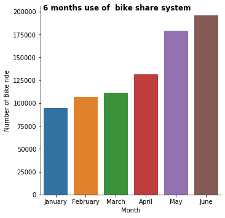

```python
# monthly use of the bike sharing system


f_graph = sb.catplot(data=df_clean, x='start_time_month', kind='count')
f_graph.set_axis_labels("Month", "Number of Bike ride")
f_graph.fig.suptitle('6 months use of  bike share system',  fontweight='semibold');
```

> As we can see, starting from march which is the spring season the number of rental of bikes increases and it reaches the highest in June which is the first month of summer seasons.

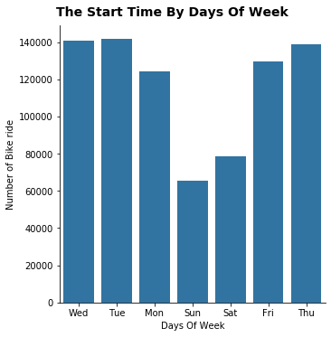

```python
# create a base color to be used in some of the graphs
base_color = sb.color_palette()[0]

# Show the start_time_dayofweek use of the bike sharing system
s_graph = sb.catplot(data=df_clean, x='start_time_dayofweek', kind='count', color = base_color)
s_graph.set_axis_labels("Days Of Week", "Number of Bike ride")
s_graph.fig.suptitle('The Start Time By Days Of Week', y=1.03, fontsize=14, fontweight='semibold');
```

> As we can see on the weekend days the bike does not have the highest number of bikers. because at the weekend they may prefer to go on a walk instead of using the bikes. so they prefer on weekday to go to work or school.

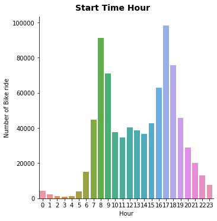

```python
# Show the start_time_hour use of the bike sharing system

t_graph = sb.catplot(data=df_clean, x='start_time_hour', kind='count')
t_graph.set_axis_labels("Hour", "Number of Bike ride")
t_graph.fig.suptitle('Start Time Hour', y=1.03, fontsize=14, fontweight='semibold');
```

> As we can see between 8:00 AM and 9:00 AM have most bikers and between 5:00 and 6:00 PM are the two peak hours. The reasons that those periods has the most bikers because it is the time people go to work and back from it as well

### Of the features you investigated, were there any unusual distributions? Did you perform any operations on the data to tidy, adjust, or change the form of the data? If so, why did you do this?

> So far nothing seems as unusual distributions for a bike-sharing system. The data reveals that the weekday has the highest number of bikers which I didn't expect.

## Bivariate Exploration

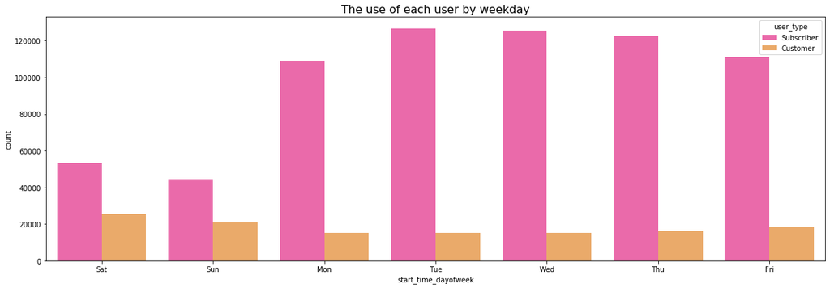

```python
## make the fiqure size
plt.figure(figsize = [20, 45]);

## size of subplot
ax = plt.subplot(6, 1, 5);


# Setting the days into order
df_clean['start_time_dayofweek'] = pd.Categorical(df_clean['start_time_dayofweek'],
                                                categories=['Sat','Sun','Mon','Tue','Wed', 'Thu','Fri'],  ordered=True)

## Show the number of use by day for each user
sb.countplot(data = df_clean, x = 'start_time_dayofweek', hue = 'user_type', palette = 'spring' ).set_title('The use of each user by weekday', fontsize=16);
```

> Tuesday has the most 'Subscriber' bikers compared to other days, Then Wednesday and Thursday are approximately similar to the number of bikers on Tuesday. On the other hand the, the highest number of 'customer' bikers on Saturday then Sunday compared to other days which is due to the weekend.

[output not shown]

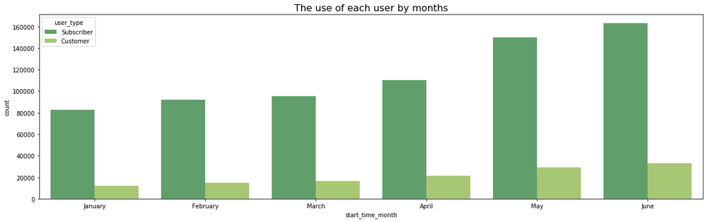

```python
## make the fiqure size
plt.figure(figsize = [20, 40]);
## size of subplot
ax = plt.subplot(6, 1, 5);

 ##Show the number of use by months for each user
sb.countplot(data = df_clean, x = 'start_time_month', hue = 'user_type', palette = 'summer').set_title('The use of each user by months', fontsize=16)
;
```

> As we can see, the share bike system trends for 'subscribers' and 'customers' during the first month of summer season which is on June

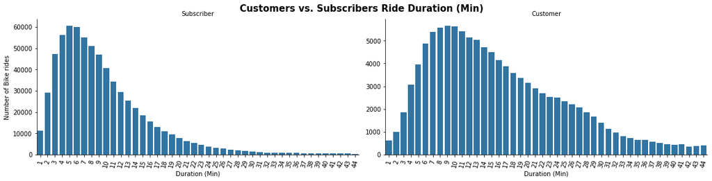

```python
# Customer Usage by Min Duration vs. Subscriber Usage by Min Duration

data = df_clean.query('duration_min < 45')

gr = sb.catplot(data=data, x = 'duration_min', col='user_type', kind='count', sharey = False, color = base_color, height=4, aspect=2);

gr.set_axis_labels('Duration (Min)', 'Number of Bike rides')
gr.set_titles('{col_name}')

gr.fig.suptitle(' Customers vs. Subscribers Ride Duration (Min)', y=1.00, fontsize=15, fontweight='bold');
gr.set_xticklabels(rotation=75);
```

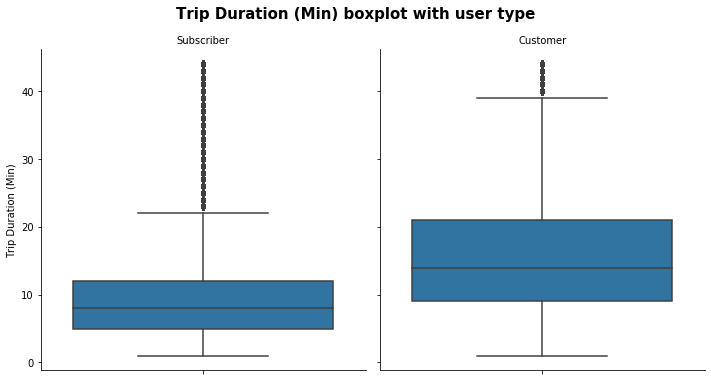

```python
#code for the boxplot duration (Min) distribution

con = df_clean.query('duration_min < 45')
g1 = sb.catplot(data=con, y='duration_min', col="user_type", kind='box')
g1.set_titles(col_template = '{col_name}')
g1.set_axis_labels("", "Trip Duration (Min)")
g1.fig.suptitle('Trip Duration (Min) boxplot with user type', y=1.05, fontsize=15, fontweight='semibold');
```

> The graphs above shows the ride duration spread in minutes to visualize the trends of Customer and Subscriber easier. For the Subscriber the ride duration is not that long, the majority are between 4 to 13 minutes and the trend from first grapgh is ( 5 minutes ). On the other hand, the Customer has ride durations longer which is quite not what I expected, it is between 8 to 22 minutes and the trend from first grapghis (9 minutes) That make us conclude that the subscriber uses the bike for short trips like school, work, or other.

### Talk about some of the relationships you observed in this part of the investigation. How did the feature(s) of interest vary with other features in the dataset?

Adding the user type to the analysis depicted different usage between customers and subscribers.

### Did you observe any interesting relationships between the other features (not the main feature(s) of interest)?

> Tuesday has the most 'Subscriber' bikers compared to other days. Saturday has the most 'Customer' bikers compared to other days. for the customer it is clear because it is weekend but for the Subscriber there is no clear reason why Tuesday is the highest.

## Multivariate Exploration

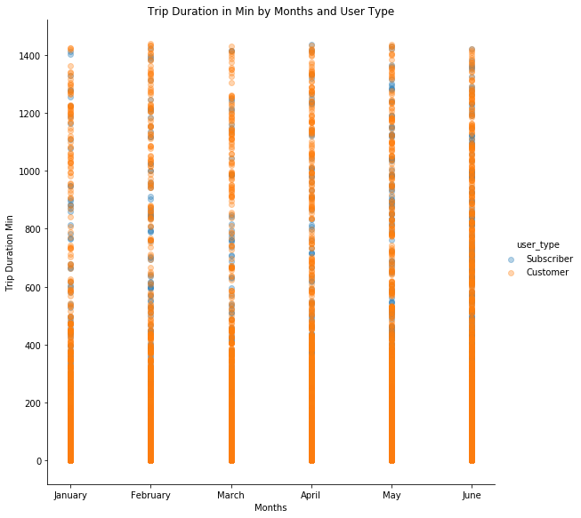

```python
## Here we have to focus on knowing if user type leads to the lower duration


# Setting the monthes into order
df_clean['start_time_month'] = pd.Categorical(df_clean['start_time_month'],
                                                categories=['January','February','March','April','May', 'June'],
                                                ordered=True)

## Here we have to focus on knowing if user type leads to the lower duration

gs = sb.FacetGrid(data =df_clean, hue = 'user_type', height = 8)
gs.map(plt.scatter, 'start_time_month','duration_min', alpha = 1/3)
gs.add_legend()

plt.title('Trip Duration in Min by Months and User Type')
plt.xlabel('Months')
plt.ylabel('Trip Duration Min');
```

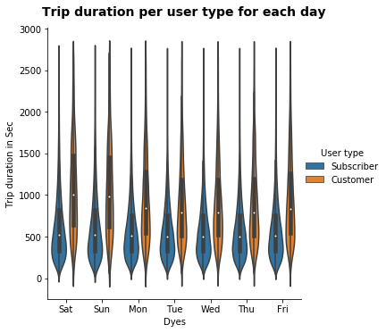

```python
## show the start_time_dayofweek by duration_sec and user_type

g = sb.catplot(data=data, x='start_time_dayofweek', y="duration_sec", hue="user_type", kind="violin")

g.set_axis_labels("Dyes", "Trip duration in Sec")
g._legend.set_title('User type')
g.fig.suptitle('Trip duration per user type for each day', y=1.03, fontsize=14, fontweight='semibold');
```

##### As we can see, the customer duration is more during the weekend especially on Sunday and Saturday. but for the subscriber, all the weekday are quite similar in the duration

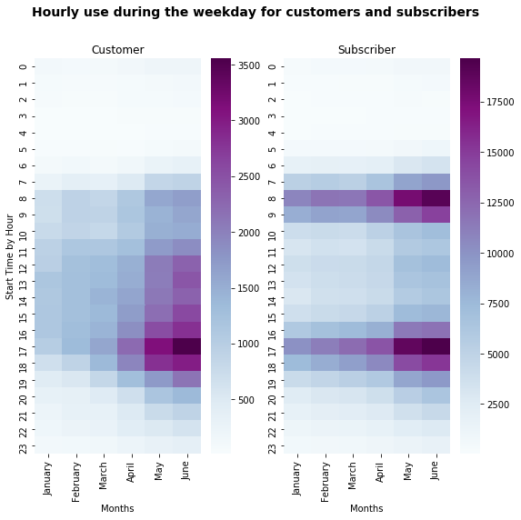

```python
# Setting the monthes into order
df_clean['start_time_month'] = pd.Categorical(df_clean['start_time_month'],
                                                categories=['January','February','March','April','May', 'June'], ordered=True)


## make the figure size
plt.figure(figsize=(9,8))
plt.suptitle('Hourly use during the weekday for customers and subscribers', fontsize=14, fontweight='semibold')

# heatmap for customers
plt.subplot(1, 2, 1)
df_cus = df_clean.query('user_type == "Customer"').groupby(["start_time_hour", "start_time_month"])["bike_id"].size().reset_index()
df_cus = df_cus.pivot("start_time_hour", "start_time_month", "bike_id")
sb.heatmap(df_cus, cmap="BuPu")

plt.title("Customer", y=1.014)
plt.xlabel('Months')
plt.ylabel('Start Time by Hour');



# heatmap for subscribers
plt.subplot(1, 2, 2)
df_subs = df_clean.query('user_type == "Subscriber"').groupby(["start_time_hour", "start_time_month"])["bike_id"].size().reset_index()
df_subs = df_subs.pivot("start_time_hour", "start_time_month", "bike_id")
sb.heatmap(df_subs, cmap="BuPu")

plt.title("Subscriber", y=1.014)
plt.xlabel('Months')
plt.ylabel('');
```

### Were there any interesting or surprising interactions between features?

```python
!jupyter nbconvert slide_deck_template.ipynb --to slides --post serve --template output_toggle
```

[output not shown]